# Part I - Prosper Loan Data Exploration

## Introduction

This document explores a dataset containing 113,937 loans with 81 variables on each loan, including loan amount, borrower rate (or interest rate), current loan status, borrower income, and many others.

## Preliminary Wrangling

```python
# import all packages and set plots to be embedded inline
import numpy as np
import pandas as pd
import matplotlib.pyplot as plt
import seaborn as sb

%matplotlib inline
```

```python
# load in the dataset into a pandas dataframe, print statistics
loan = pd.read_csv(r'C:\Users\JusticeAnnan\Desktop\AO Holdings\Online Learning\Udacity Data Analyst\Projects\Project 3\Working 3\prosperLoanData.csv')
```

```python
# high-level overview of data shape and composition
print(loan.shape)
print(loan.dtypes)
```

```
(113937, 81)
ListingKey                      object
ListingNumber                    int64
ListingCreationDate             object
CreditGrade                     object
Term                             int64
                                ...
PercentFunded                  float64
Recommendations                  int64
InvestmentFromFriendsCount       int64
InvestmentFromFriendsAmount    float64
Investors                        int64
Length: 81, dtype: object
```

```python
loan.head()
```

|  | ListingKey | ListingNumber | ListingCreationDate | CreditGrade | Term | LoanStatus | ClosedDate | BorrowerAPR | BorrowerRate | LenderYield | ... | LP_ServiceFees | LP_CollectionFees | LP_GrossPrincipalLoss | LP_NetPrincipalLoss | LP_NonPrincipalRecoverypayments | PercentFunded | Recommendations | InvestmentFromFriendsCount | InvestmentFromFriendsAmount | Investors |
| --- | --- | --- | --- | --- | --- | --- | --- | --- | --- | --- | --- | --- | --- | --- | --- | --- | --- | --- | --- | --- | --- |
| 0 | 1021339766868145413AB3B | 193129 | 2007-08-26 19:09:29.263000000 | C | 36 | Completed | 2009-08-14 00:00:00 | 0.16516 | 0.1580 | 0.1380 | ... | -133.18 | 0.0 | 0.0 | 0.0 | 0.0 | 1.0 | 0 | 0 | 0.0 | 258 |
| 1 | 10273602499503308B223C1 | 1209647 | 2014-02-27 08:28:07.900000000 | NaN | 36 | Current | NaN | 0.12016 | 0.0920 | 0.0820 | ... | 0.00 | 0.0 | 0.0 | 0.0 | 0.0 | 1.0 | 0 | 0 | 0.0 | 1 |
| 2 | 0EE9337825851032864889A | 81716 | 2007-01-05 15:00:47.090000000 | HR | 36 | Completed | 2009-12-17 00:00:00 | 0.28269 | 0.2750 | 0.2400 | ... | -24.20 | 0.0 | 0.0 | 0.0 | 0.0 | 1.0 | 0 | 0 | 0.0 | 41 |
| 3 | 0EF5356002482715299901A | 658116 | 2012-10-22 11:02:35.010000000 | NaN | 36 | Current | NaN | 0.12528 | 0.0974 | 0.0874 | ... | -108.01 | 0.0 | 0.0 | 0.0 | 0.0 | 1.0 | 0 | 0 | 0.0 | 158 |
| 4 | 0F023589499656230C5E3E2 | 909464 | 2013-09-14 18:38:39.097000000 | NaN | 36 | Current | NaN | 0.24614 | 0.2085 | 0.1985 | ... | -60.27 | 0.0 | 0.0 | 0.0 | 0.0 | 1.0 | 0 | 0 | 0.0 | 20 |

5 rows × 81 columns

```python
loan.info()
```

```
<class 'pandas.core.frame.DataFrame'>
RangeIndex: 113937 entries, 0 to 113936
Data columns (total 81 columns):
 #   Column                               Non-Null Count   Dtype
---  ------                               --------------   -----
 0   ListingKey                           113937 non-null  object
 1   ListingNumber                        113937 non-null  int64
 2   ListingCreationDate                  113937 non-null  object
 3   CreditGrade                          28953 non-null   object
 4   Term                                 113937 non-null  int64
 5   LoanStatus                           113937 non-null  object
 6   ClosedDate                           55089 non-null   object
 7   BorrowerAPR                          113912 non-null  float64
 8   BorrowerRate                         113937 non-null  float64
 9   LenderYield                          113937 non-null  float64
```

[output cut: 73 more lines]

- from the information statistics, columns that are not equal to 113937 entries have missing values.
- I will then go ahead and drop the missing values in the BorrowerAPR column

```python
# displaying values for in_reply_to_user_id
loan.BorrowerAPR.isnull().sum()
```

```
25
```

```python
# dropping values for BorrowerAPR
loan.drop(loan[(loan['BorrowerAPR'].isnull())].index, inplace=True)
```

```python
loan.info()
```

```
<class 'pandas.core.frame.DataFrame'>
Int64Index: 113912 entries, 0 to 113936
Data columns (total 81 columns):
 #   Column                               Non-Null Count   Dtype
---  ------                               --------------   -----
 0   ListingKey                           113912 non-null  object
 1   ListingNumber                        113912 non-null  int64
 2   ListingCreationDate                  113912 non-null  object
 3   CreditGrade                          28928 non-null   object
 4   Term                                 113912 non-null  int64
 5   LoanStatus                           113912 non-null  object
 6   ClosedDate                           55064 non-null   object
 7   BorrowerAPR                          113912 non-null  float64
 8   BorrowerRate                         113912 non-null  float64
 9   LenderYield                          113912 non-null  float64
```

[output cut: 73 more lines]

```python
# Convert ProsperRating, LoanStatus, and EmploymentStatus into ordered categorical types
ordinal_var_dict = {'ProsperRating (Alpha)': ['HR','E','D','C','B','A','AA'],
                    'EmploymentStatus': ['Not available', 'Not employed', 'Part-time', 'Full-time',
                                         'Self-employed', 'Employed', 'Retired', 'Other']}

for var in ordinal_var_dict:
    ordered_var = pd.api.types.CategoricalDtype(ordered = True,
                                                categories = ordinal_var_dict[var])
    loan[var] = loan[var].astype(ordered_var)
```

```python
# descriptive statistics for numeric variables
print(loan.describe())
```

```
       ListingNumber           Term    BorrowerAPR   BorrowerRate  \
count   1.139120e+05  113912.000000  113912.000000  113912.000000
mean    6.280235e+05      40.831308       0.218828       0.192786
std     3.279803e+05      10.437112       0.080364       0.074809
min     7.000000e+01      12.000000       0.006530       0.000000
25%     4.012110e+05      36.000000       0.156290       0.134000
50%     6.006245e+05      36.000000       0.209760       0.184000
75%     8.927982e+05      36.000000       0.283810       0.250000
max     1.255725e+06      60.000000       0.512290       0.497500

         LenderYield  EstimatedEffectiveYield  EstimatedLoss  EstimatedReturn  \
count  113912.000000             84853.000000   84853.000000     84853.000000
mean        0.182723                 0.168661       0.080306         0.096068
std         0.074506                 0.068467       0.046764         0.030403
min        -0.010000                -0.182700       0.004900        -0.182700
25%         0.124500                 0.115670       0.042400         0.074080
50%         0.173000                 0.161500       0.072400         0.091700
75%         0.240000                 0.224300       0.112000         0.116600
max         0.492500                 0.319900       0.366000         0.283700

       ProsperRating (numeric)  ProsperScore  ...  LP_ServiceFees  \
count             84853.000000  84853.000000  ...   113912.000000
mean                  4.072243      5.950067  ...      -54.734997
std                   1.673227      2.376501  ...       60.677981
min                   1.000000      1.000000  ...     -664.870000
25%                   3.000000      4.000000  ...      -73.180000
50%                   4.000000      6.000000  ...      -34.450000
75%                   5.000000      8.000000  ...      -13.930000
max                   7.000000     11.000000  ...       32.060000

       LP_CollectionFees  LP_GrossPrincipalLoss  LP_NetPrincipalLoss  \
count      113912.000000          113912.000000        113912.000000
mean          -14.244741             700.600068           681.570049
std           109.244070            2388.753377          2357.404098
min         -9274.750000             -94.200000          -954.550000
25%             0.000000               0.000000             0.000000
50%             0.000000               0.000000             0.000000
75%             0.000000               0.000000             0.000000
max             0.000000           25000.000000         25000.000000

       LP_NonPrincipalRecoverypayments  PercentFunded  Recommendations  \
count                    113912.000000  113912.000000    113912.000000
mean                         25.148204       0.998583         0.048037
std                         275.687933       0.017921         0.332389
min                           0.000000       0.700000         0.000000
25%                           0.000000       1.000000         0.000000
50%                           0.000000       1.000000         0.000000
75%                           0.000000       1.000000         0.000000
max                       21117.900000       1.012500        39.000000

       InvestmentFromFriendsCount  InvestmentFromFriendsAmount      Investors
count               113912.000000                113912.000000  113912.000000
mean                     0.023465                    16.554383      80.491792
std                      0.232437                   294.577640     103.244281
min                      0.000000                     0.000000       1.000000
25%                      0.000000                     0.000000       2.000000
50%                      0.000000                     0.000000      44.000000
75%                      0.000000                     0.000000     115.000000
max                     33.000000                 25000.000000    1189.000000

[8 rows x 61 columns]
```

### What is the structure of your dataset?

> This document explores a dataset containing 113,937 loans with 81 variables on each loan, including loan amount, borrower rate (or interest rate), current loan status, borrower income, and many others.

### What is/are the main feature(s) of interest in your dataset?

> The main feature(s) of interest is to look at the determinants that affects a borrower's Annual Percentage Rate (APR) for a loan.

### What features in the dataset do you think will help support your investigation into your feature(s) of interest?

> I expect that Loan Amount and Prosper Rating (Alpha) will have the strongest effect on a borrower's annual percentage rate (APR): the larger the Loan Amount and the better the Prosper Rating, the lower the APR. I also think that term, stated monthly income, employment status, is borrower a home owner and current in group will have effects on the APR.

## Univariate Exploration

I'll start by looking at the distribution of the main variable of interest: BorrowerAPR.

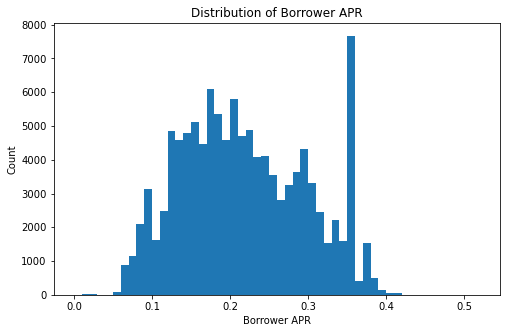

```python
# Distribution of Borrower APR
bins = np.arange(0, loan.BorrowerAPR.max()+0.01, 0.01)

plt.figure(figsize=[8, 5])
plt.hist(data = loan, x = 'BorrowerAPR', bins = bins)
plt.xlabel('Borrower APR')
plt.ylabel('Count')
plt.title('Distribution of Borrower APR')
plt.show;
```

The borrower APR distribution appears to be multimodal with some peaks around 0.1, 0.2 and 0.3. Most curiously the largest peak falls right between 0.3 and 0.4.

Next up is the first predictor variable of interest: LoanOriginalAmount.

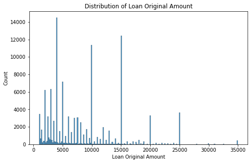

```python
# Distribution of Loan Original Amount
plt.figure(figsize = [8,5])
sb.histplot(loan.LoanOriginalAmount, kde = False, bins = 200)
plt.xlabel('Loan Original Amount')
plt.ylabel('Count')
plt.title('Distribution of Loan Original Amount')
plt.show;
```

- The original loan amount distribution shows that there are a number of high and low spikes. The high spikes include;
- 2k, 3k, 4k, 5k, 10k, 15k, 20k and 25k

  The low spikes include;
- 6k, 7k, 12k, 13k, 14k, 17k, 35k and many others

I will now look at the distribution of the ProsperRating (Alpha)

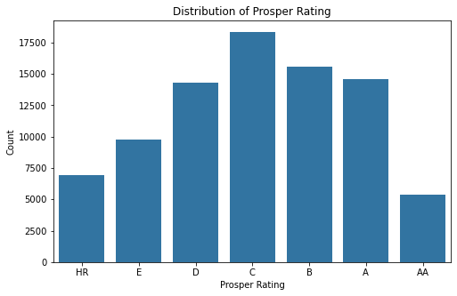

```python
# Distribution of Prosper Rating
plt.figure(figsize=[8, 5])
default_color = sb.color_palette()[0]
sb.countplot(data = loan, x = 'ProsperRating (Alpha)', color = default_color)
plt.xlabel('Prosper Rating')
plt.ylabel('Count')
plt.title('Distribution of Prosper Rating')
plt.show;
```

The ratings chart in the order of highest to lowest are;

- C, B, A, D, E, HR and AA

Stated Monthly Income variable will now be examined

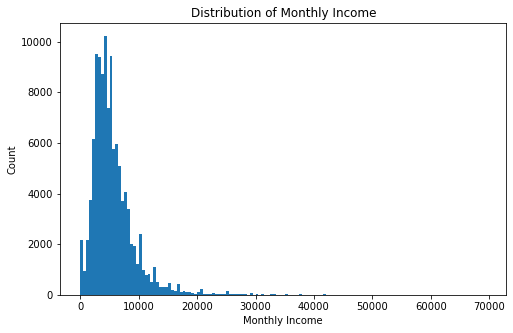

```python
# Distribution of StatedMonthlyIncome
plt.figure(figsize = [8, 5])

bins = np.arange(0, 70000, 500)
plt.hist(data = loan, x = 'StatedMonthlyIncome', bins= bins)
plt.xlabel('Monthly Income')
plt.ylabel('Count')
plt.title('Distribution of Monthly Income');
```

The distribution of stated monthly income appears to be skewed to the right.

I will now move on to look at the distribution of Term, EmploymentStatus, IsBorrowerHomeowner and CurrentlyInGroup variables.

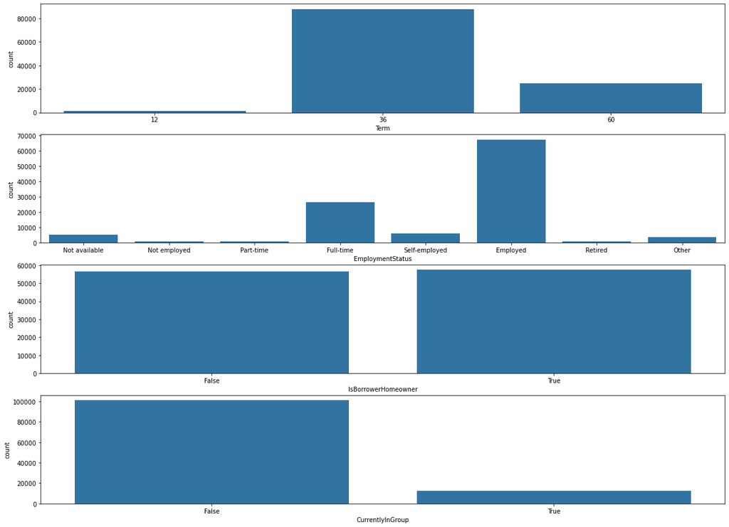

```python
# let's plot all four together to get an idea of each variable's distribution.

fig, ax = plt.subplots(nrows=4, figsize = [20,15])
default_color = sb.color_palette()[0]
sb.countplot(data = loan, x = 'Term', color = default_color, ax = ax[0])
sb.countplot(data = loan, x = 'EmploymentStatus', color = default_color, ax = ax[1])
sb.countplot(data = loan, x = 'IsBorrowerHomeowner', color = default_color, ax = ax[2])
sb.countplot(data = loan, x = 'CurrentlyInGroup', color = default_color, ax = ax[3]);
```

Most loans have a duration of 36 months. Most of the borrowers are also employed. In terms of borrowers being home owners, just about a little indicated true over those who indicated false. Majority of the borrowers also indicated that they were not in any group.

### Discuss the distribution(s) of your variable(s) of interest. Were there any unusual points? Did you need to perform any transformations?

The distribution of borrowers APR looks multimodal with the highest peak between 0.3 and 0.4. Most of the values are at the range of 0.05 and 0.4. No need for any transformation as there are no unusual points.

### Of the features you investigated, were there any unusual distributions? Did you perform any operations on the data to tidy, adjust, or change the form of the data? If so, why did you do this?

The distributions of stated monthly income is highly skewed to the right with most monthly incomes being less than 30k. No need for any transformation as there are no unusual distributions.

## Bivariate Exploration

To start off with, I want to look at the pairwise correlations present between features in the data.

```python
numeric_vars = ['BorrowerAPR', 'LoanOriginalAmount', 'StatedMonthlyIncome']
categoric_vars = ['ProsperRating (Alpha)', 'Term', 'EmploymentStatus', 'IsBorrowerHomeowner', 'CurrentlyInGroup']
```

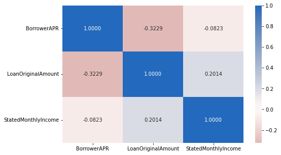

```python
# correlation plot
plt.figure(figsize = [8, 5])
sb.heatmap(loan[numeric_vars].corr(), annot = True, fmt = '.4f',
           cmap = 'vlag_r', center = 0)
plt.show();
```

[output not shown]

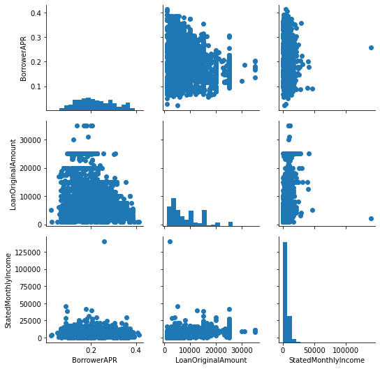

```python
# plot matrix: sample 3000 loans so that plots are clearer and they render faster
print("loan.shape=",loan.shape)
loan_samp = loan.sample(n=3000, replace = False)
print("loan_samp.shape=",loan_samp.shape)

g = sb.PairGrid(data = loan_samp, vars = numeric_vars)
g = g.map_diag(plt.hist, bins = 20)
g.map_offdiag(plt.scatter);
```

The matrix chart shows that there is a negative correlation between BorrowerAPR and LoanOriginalAmount. This indicates that the higher the LoanOriginalAmount, the lower the BorrowerAPR.

Let's now move on and examine how the numerical variables (BorrowerAPR, LoanOriginalAmount and StatedMonthlyIncome) correlate with the categorical variables.

[output not shown]

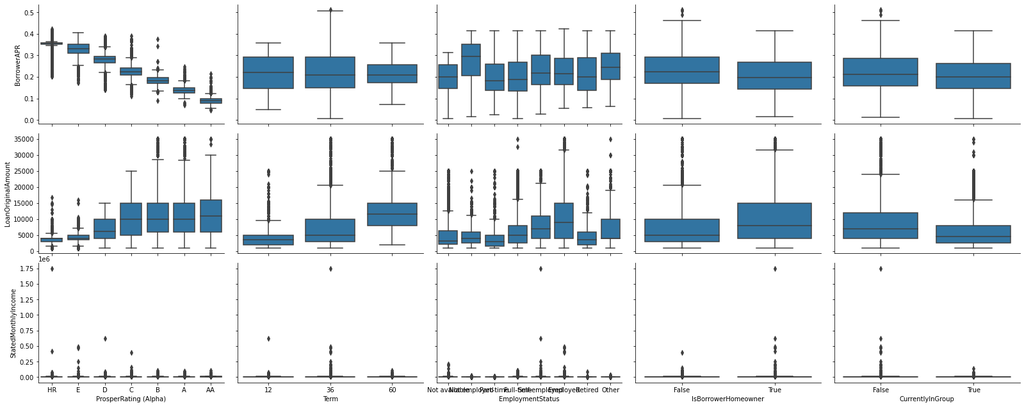

```python
# plot matrix of numeric features against categorical features.

def boxgrid(x, y, **kwargs):
    """ Quick hack for creating box plots with seaborn's PairGrid. """
    default_color = sb.color_palette()[0]
    sb.boxplot(x, y, color = default_color)

plt.figure(figsize = [20, 20])
g = sb.PairGrid(data = loan, y_vars = ['BorrowerAPR', 'LoanOriginalAmount', 'StatedMonthlyIncome'],
                x_vars = categoric_vars, size = 3, aspect = 1.5)
g.map(boxgrid);
```

As expected, there is a negative relationship between borrower APR and prosper rating. That means the better the rating, the lower the APR. Borrowers also get more loan amounts with an increase in rating. Loan amount also increases with an increase in term. Loan amount is also high among borrowers who are employed.

Finally, let's look at relationships between the categorical features.

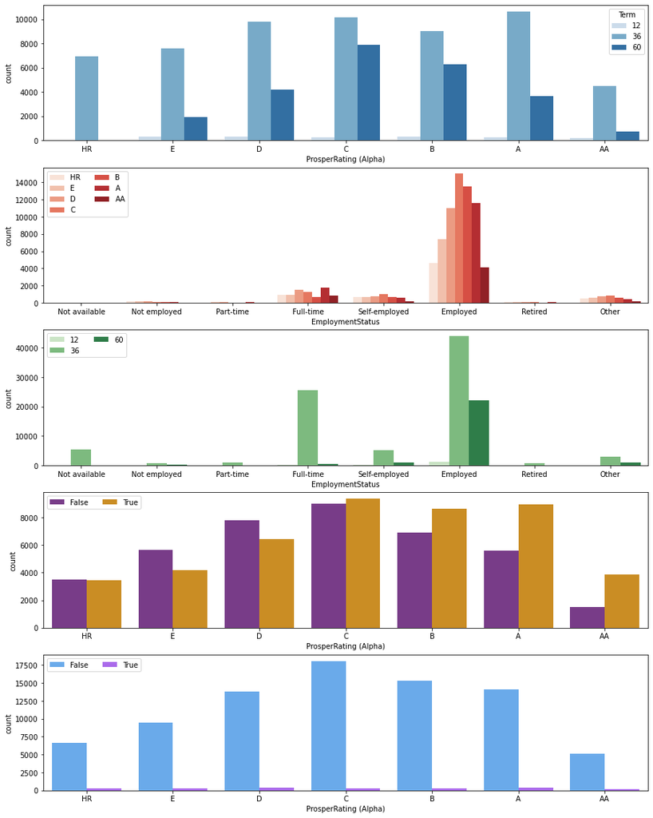

```python
# since there's only four subplots to create, using the full data should be fine.
plt.figure(figsize = [15, 20])

# subplot 1: ProsperRating (Alpha) vs Term
plt.subplot(5, 1, 1)
sb.countplot(data = loan, x = 'ProsperRating (Alpha)', hue = 'Term', palette = 'Blues')

# subplot 2: EmploymentStatus vs. ProsperRating (Alpha)
ax = plt.subplot(5, 1, 2)
sb.countplot(data = loan, x = 'EmploymentStatus', hue = 'ProsperRating (Alpha)', palette = 'Reds')
ax.legend(ncol = 2, loc = 'upper left')

# subplot 3: EmploymentStatus vs. Term,
ax = plt.subplot(5, 1, 3)
sb.countplot(data = loan, x = 'EmploymentStatus', hue = 'Term', palette = 'Greens')
ax.legend(loc = 'upper left', ncol = 2)

# subplot 4: ProsperRating (Alpha) vs. IsBorrowerHomeowner
ax = plt.subplot(5, 1, 4)
sb.countplot(data = loan, x = 'ProsperRating (Alpha)', hue = 'IsBorrowerHomeowner', palette = 'CMRmap')
ax.legend(loc = 'upper left', ncol = 2)

# subplot 5: ProsperRating (Alpha) vs. CurrentlyInGroup
ax = plt.subplot(5, 1, 5)
sb.countplot(data = loan, x = 'ProsperRating (Alpha)', hue = 'CurrentlyInGroup', palette = 'cool')
ax.legend(loc = 'upper left', ncol = 2)

plt.show()
```

I will now examine the relationship between borrower APR and loan original amount.

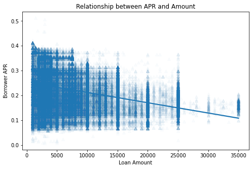

```python
# Relationship between APR and Amount
plt.figure(figsize = [8, 5])
sb.regplot(data = loan, x = 'LoanOriginalAmount', y = 'BorrowerAPR', scatter_kws={'alpha':1/50}, marker= '^')
plt.xlabel('Loan Amount')
plt.ylabel('Borrower APR')
plt.title('Relationship between APR and Amount');
```

The graph shows that there is a negative correlation between Borrower APR and Loan Amount. The more there is an increase in the Loan Amount, the lower the APR is for the borrower.

### Talk about some of the relationships you observed in this part of the investigation. How did the feature(s) of interest vary with other features in the dataset?

The borrower APR has a negative correlation to the loan original amount, which means that the lower the APR, the more the loan amount.

## Multivariate Exploration

The main thing I want to explore in this part of the analysis is how the categorical variable (Prosper rating, employment status, term and borrower being a house owner) play into the relationship between borrower APR and loan original amount.

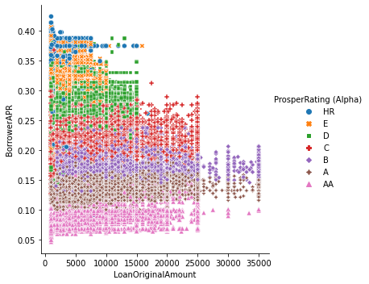

```python
# Graph for Borrower APR, Loan Amount and Prosper Rating
plt.figure(figsize = [20, 15])
sb.relplot(data = loan, x ='LoanOriginalAmount', y = 'BorrowerAPR', kind = 'scatter', style = 'ProsperRating (Alpha)',
           hue = 'ProsperRating (Alpha)');
plt.show();
```

From poor to better ratings, borrowers with ratings of HR have a high APR with the lowest amount in terms of loan amount. This is followed by E, D, C, B, A and AA respectively. This is true because borrowers with poor ratings tend to have high interest rate or APR with little accessibility to loan facilities where as borrowers with better ratings tend to have low interest rate or APR with better accessibility to loan facilities.

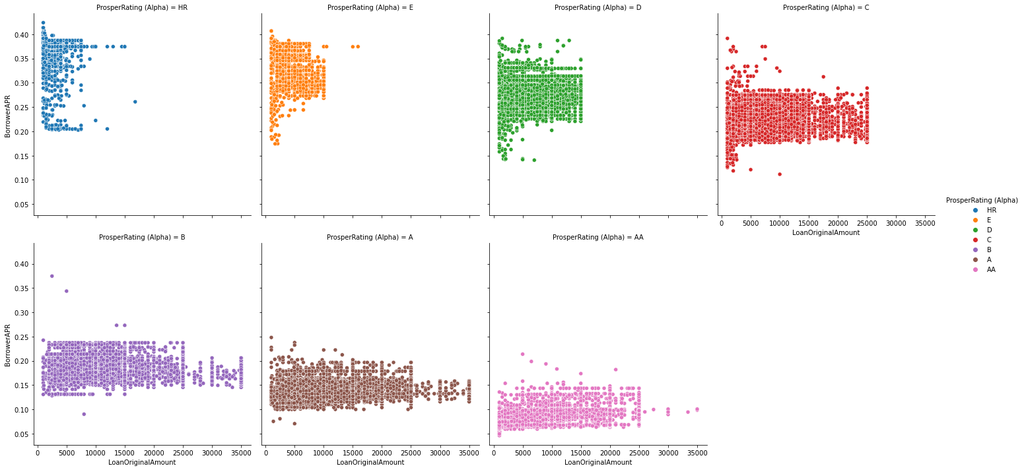

```python
# Relationship between Rating, Loan Amount, and Borrower APR
sb.relplot(data = loan, x ='LoanOriginalAmount', y = 'BorrowerAPR', kind = 'scatter', hue = 'ProsperRating (Alpha)',
           col = 'ProsperRating (Alpha)', col_wrap = 4);
plt.show();
```

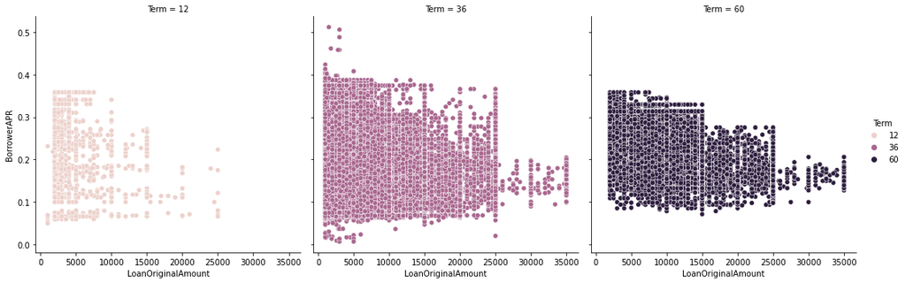

```python
# Term effect on Loan Amount and Borrower APR
plt.figure(figsize = [20, 15])
sb.relplot(data = loan, x ='LoanOriginalAmount', y = 'BorrowerAPR', kind = 'scatter', hue = 'Term', col = 'Term')
plt.show();
```

The relational plot shows that there is not much of an effect of Term on Loan Amount and APR though it appears that most loans have a duration of 36 months.

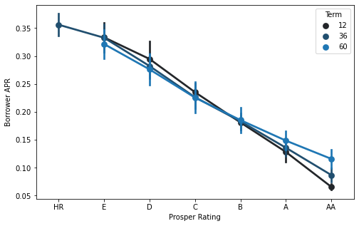

```python
# The relationship between Prosper Rating, APR and Term
plt.figure(figsize = [8, 5])
base_color = sb.color_palette()[0]
sb.pointplot(data=loan, x='ProsperRating (Alpha)', y='BorrowerAPR', hue='Term', color=base_color, ci='sd', linestyles="solid",)
plt.xlabel('Prosper Rating')
plt.ylabel('Borrower APR');
```

From HR to C, an increase in term is matched by a decrease in borrower APR but for borrowers with B to AA ratings, an increase in term corresponds to an increase in the borrower APR.

I will now look at how rating and term affects stated monthly income and loan original amount.

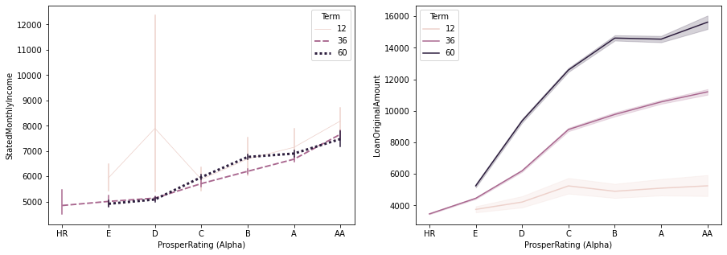

```python
plt.figure(figsize = [15, 5])

# StatedMonthlyIncome on left
plt.subplot(1, 2, 1)
sb.lineplot(data = loan, x = 'ProsperRating (Alpha)', y = 'StatedMonthlyIncome', hue = 'Term',
           style = 'Term', err_style='bars', size = 'Term')

# DebtToIncomeRatio on right
plt.subplot(1, 2, 2)
sb.lineplot(data = loan, x = 'ProsperRating (Alpha)', y = 'LoanOriginalAmount', hue = 'Term');
```

I will now look at the effect of how owning a home affects APR and Loan Amount

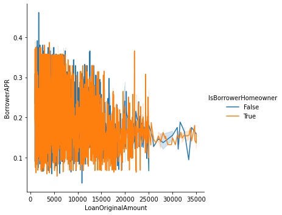

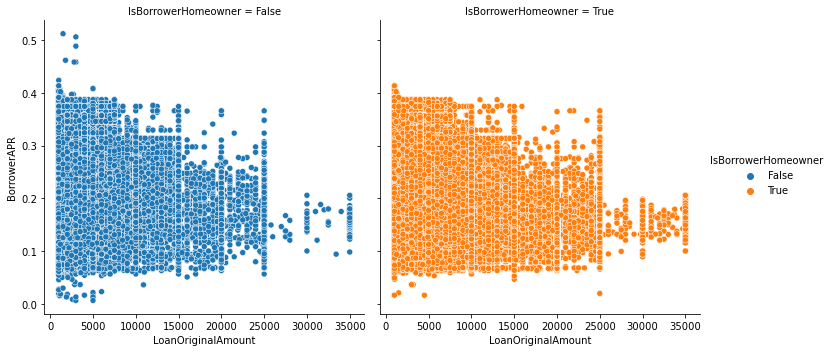

```python
# Effect of Is Borrower a Home Owner on APR and Loan Amount
plt.figure(figsize = [20, 15])
sb.relplot(data = loan, x ='LoanOriginalAmount', y = 'BorrowerAPR', kind = 'line', hue = 'IsBorrowerHomeowner')

sb.relplot(data = loan, x ='LoanOriginalAmount', y = 'BorrowerAPR', kind = 'scatter', hue = 'IsBorrowerHomeowner',
          col = 'IsBorrowerHomeowner')
plt.show();
```

It looks like whether a borrower owns a home or not does not have any significant effect on the relationship between borrower's APR and loan amount even though very few borrowers who are not home owners have very high APR compared to those who are home owners.

Now, let us examine how being in a group affects APR and Loan Amount

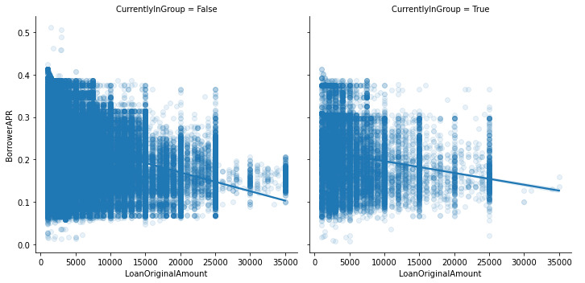

```python
# Prosper rating effect on relationship of APR and loan amount
m=sb.FacetGrid(data=loan, height=5, col='CurrentlyInGroup')
m.map(sb.regplot, 'LoanOriginalAmount', 'BorrowerAPR', scatter_kws={'alpha':0.1});
m.add_legend();
```

Whether a borrower is in a group or not does not have any significant effect on the relationship between borrower's APR and loan amount.

## Conclusions

In conclusion, there is a negative correlation between Borrower APR and Loan Original Amount. There is also a negative relationship between borrower APR and Prosper Rating (Alpha). However, the borrower APR decrease with the increase of borrow term for borrowers with HR-C raings. But for borrowers with B-AA ratings, the APR increase with the increase of borrow term. The feature 'IsBorrowerHomeowner' and 'CurrentlyInGroup' do not really have an impact on the correlation between Borrower APR and Loan Amount. However, borrowers who are home owners tend to have better ratings than those who are not home owners.